# Reproducible Research Project 1

Praveen Dua

September 17, 2015

### Loading the dataset

```r
 activity <- read.csv("activity.csv");
```

### Mean and Median of steps taken per day

```r
totalsteps <- tapply(activity$steps, activity$date, sum);
meansteps <- round(mean(totalsteps, na.rm=TRUE));
mediansteps <- round(median(totalsteps, na.rm=TRUE))
```

Mean number of steps per day = 10766

Median number of steps per day = 10765

### Average Daily Activity Pattern

To understand the average daily activity pattern, we will look at the time series plot of the average number of steps during each interval, averaged across the days in the dataset

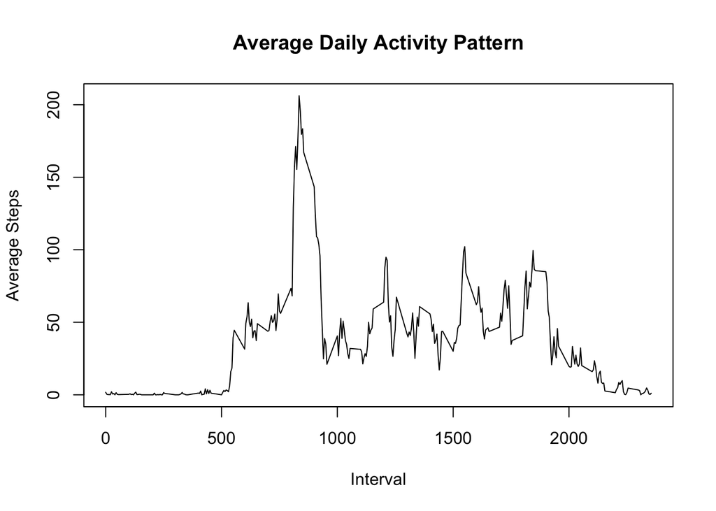

```r
intervalsteps <- tapply(activity$steps, activity$interval, mean, na.rm=TRUE);
maxidx <- which.max(intervalsteps);
intervalnames <- names(intervalsteps);
plot(intervalnames,intervalsteps, type="l", xlab="Interval", ylab="Average Steps", main="Average Daily Activity Pattern");
```

We observe that the interval with the maximum average number of steps (206) occurs for interval 835.

### Analyzing the impact of missing values

We will impute the missing values with the average value for that interval and observe how it impacts the average daily activity pattern below :

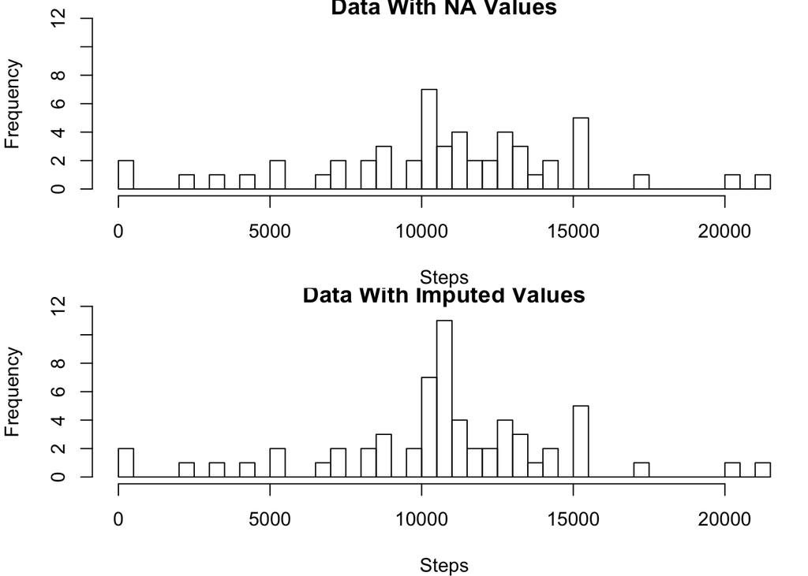

```r
dfimputed <- transform(activity, steps = ifelse(is.na(steps), intervalsteps[as.character(interval)], steps));
imputedtotalsteps <- tapply(dfimputed$steps, dfimputed$date, sum);
imputedmean <- mean(imputedtotalsteps);
imputedmedian <- median(imputedtotalsteps);
par(mfrow=c(2,1), mar=c(4,4,.5,.5));
hist(totalsteps, breaks=40, ylim=c(0,12), xlab="Steps", main="Data With NA Values");
hist(imputedtotalsteps, breaks=40, ylim=c(0,12), xlab="Steps", main="Data With Imputed Values");
```

For the dataset with imputed values, mean = 10766 and median = 10766

There is no change in the mean number of steps between the imputed and original dataset. This is likely due to the fact that the mean values for interval were used for the imputation.

The median, however, is in closer agreement with the mean for the imputed dataset.

### Weekday vs. Weekend activity patterns

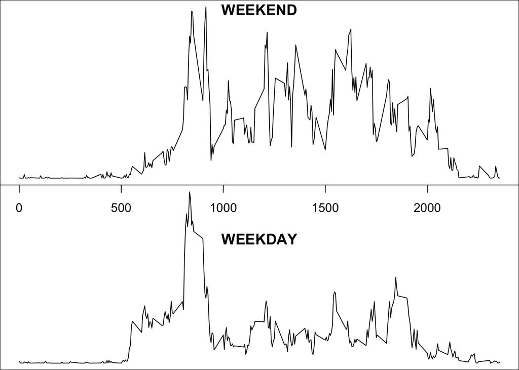

```r
dfextended <- transform(dfimputed, weekday = ifelse(weekdays(as.POSIXct(date)) %in% c('Saturday', 'Sunday'), "weekend", "weekday"));
weekdayintervalsteps <- data.frame(tapply(dfextended$steps, list(dfextended$interval, dfextended$weekday), mean, na.rm=TRUE));
par(mfrow=c(2,1), mar=c(0,0,0,0));
plot(intervalnames, weekdayintervalsteps$weekend, type="l");
title("WEEKEND", line=-1);
plot(intervalnames, weekdayintervalsteps$weekday, type="l");
title("WEEKDAY", line=-4);
```

This clearly shows a generally higher level of activity throughout the day during the weekend as opposed to a reduced activity during the rest of the day after the morning peak activity during the weekdays.